# github_test-Copy1

$\textbf{Sonification 3.1}$ Sonification of a distribution and a gradient after that?

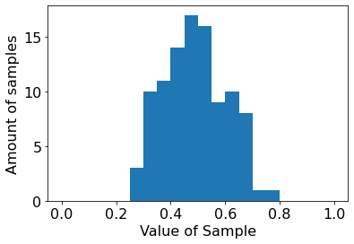

[interactive chart not shown]

$\textbf{Sonification 3.4}$ Histogram of 100 samples drawn from B(9,9) and corresponding sonification.

[video not shown]

$\textbf{Sonification 3.5}$ 60 Histograms of 100 samples each drawn from B(9,9) and corresponding sonification.

[video not shown]

$\textbf{Sonification 3.6}$ Sonifiation of two random variabes. Again, 100 samples were drawn from B(9,9) 60 times for both random variables.

[interactive chart not shown]

$\textbf{Sonification 3.6.1}$ Only the first variable sonified by the piano

[interactive chart not shown]

$\textbf{Sonification 3.6.2}$ Only the second variable sonified by the cello

[video not shown]

$\textbf{Sonification 3.7}$ Sonifiation of two random variabes. Again, 100 samples were drawn from B(9,9) 60 times for both random variables. this time the left variable was sonified through a Bass with low pitch. The right right was sonified through a pinao with high pitch. Addtionally, the Bass was only played on the left channel, and the piano on the right channel.

[interactive chart not shown]

$\textbf{Sonification 3.7.1}$ Sonification of only the first variable with the bass

[interactive chart not shown]

$\textbf{Sonification 3.7.2}$ Sonification of only the second variable through with the piano

[video not shown]

$\textbf{Sonification 3.7.3}$ Sonification of both variables without separation of sound source